# MA5761 Homework #4

Karthik Garimella

For homework assignments in this course, you will be provided with a knitted R notebook and the .rmd file used to create it. You are *encouraged* (but not required) to use the .rmd file as a template for your solutions.

## Multivariate Normal Distribution

Write a function which generates a sample from the multivariate normal distribution with mean vector $\boldsymbol{\mu}$ and covariance matrix $\boldsymbol{\Sigma}$. The function should take the arguments `n` (the sample size), `mu` (the mean vector), and `sigma` (the covariance matrix).

Your function should use the Cholesky decomposition of the covariance matrix $\boldsymbol{\Sigma}$ to perform an appropriate transformation, and should return a matrix of dimensions $n\times p$, where $n$ is the requested sample size and $p$ is the dimension of the multivariate distribution (i.e. the length of the mean vector, or the number of rows/columns of the covariance matrix).

Test your function by generating a sample of $n=10^3$ of vectors from the multivariate distribution with
$$\boldsymbol{\mu}=(92.4,
56.6, 51.8, 14.7, 27.8),
\quad
\boldsymbol{\Sigma}=\begin{pmatrix}
6.4&3.7&2.5&1.0&2.2\\
3.7&8.3&0.4&0.8&2.4\\
2.5&0.4&7.3&-0.5&0.9\\
1.0&0.8&-0.5&0.7&0.4\\
2.2&2.4&0.9&0.4&3.8\end{pmatrix}$$

This distribution is used to model a set of morphological measurements on a population of opossums in Australia:

- Head length, in mm
- Skull width, in mm
- Ear conch length, in mm
- Eye width, in mm
- Chest girth, in cm

Create a scatterplot matrix with this sample. Which pair of measurements has the strongest correlation? Estimate this from your plot, and verify this by investigating the sample correlation matrix of your sample.

###### Multivariate Normal Distribution Function

```r
MND <- function(n , mu, sigma){

  R <- chol(sigma)
  p <- length(mu)

  Z <- matrix(rnorm(n*p), nrow = n, ncol = p)
  Z %*% R + matrix(mu, nrow = n, ncol = p, byrow = T)

}
```

###### Initializing Sigma and Mu

```r
sigma_matrix <- matrix(c(6.4, 3.7, 2.5, 1.0, 2.2,
                         3.7, 8.3, 0.4, 0.8, 2.4,
                         2.5, 0.4, 7.3, -0.5, 0.9,
                         1.0, 0.8, -0.5, 0.7, 0.4,
                         2.2, 2.4, 0.9, 0.4, 3.8), nrow = 5, ncol = 5, byrow = T) # Sigma

mu_mu <- c(92.4, 56.6, 51.8, 14.7, 27.8) # Mu
```

###### Declaring variable Z for the Multivariate Normal Distribution Function

```r
Z <- MND(10^3, mu_mu, sigma_matrix)
```

###### Calling libraries

```r
library(ggplot2)
library(GGally)
```

###### Getting colMeans of Z

```r
col_names <- c('Head length', 'Skull width','Ear conch length','Eye width','Chest girth')

colnames(Z) <- col_names

colMeans(Z)
```

```
##      Head length      Skull width Ear conch length        Eye width
##         92.45393         56.69545         51.88394         14.72255
##      Chest girth
##         27.90103
```

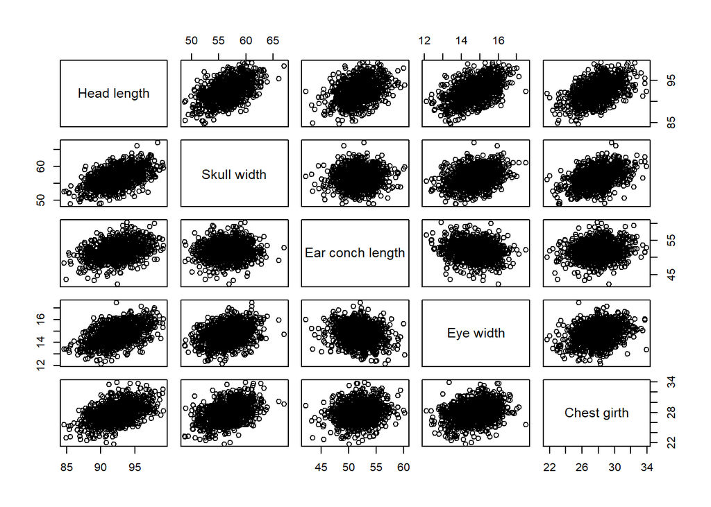

```r
pairs(Z)
```

###### Scatter Plot for ggally

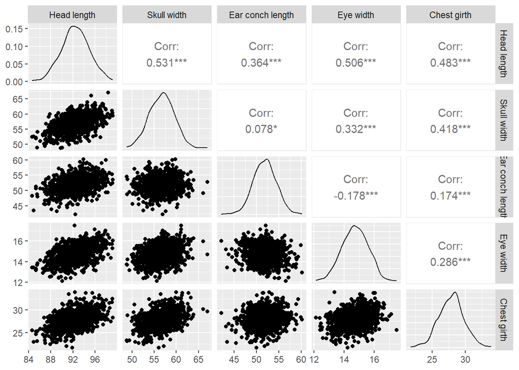

```r
ggpairs(as.data.frame(Z))
```

###### Matrix Correlation

```r
cor(Z)
```

```
##                  Head length Skull width Ear conch length  Eye width
## Head length        1.0000000   0.5307231        0.3642791  0.5059426
## Skull width        0.5307231   1.0000000        0.0778314  0.3316399
## Ear conch length   0.3642791   0.0778314        1.0000000 -0.1777405
## Eye width          0.5059426   0.3316399       -0.1777405  1.0000000
## Chest girth        0.4834959   0.4180742        0.1743256  0.2859971
##                  Chest girth
## Head length        0.4834959
## Skull width        0.4180742
## Ear conch length   0.1743256
## Eye width          0.2859971
## Chest girth        1.0000000
```

#### Skull Width and Head Length have the strongest correlation as there seems to be a kind of pattern in the scatter plot and just does not look completely random x,y plot.

## Multivariate Student’s *t* Distribution

One version of the multivariate *t* distribution is defined as the probability distribution of the random vector **t**, where

$$\mathbf{t}=\frac1{\sqrt{W/\nu}}\mathbf{X}+\boldsymbol{\mu}$$

In the above,

- $\mathbf{X}$ has the multivariate normal distribution with a zero mean vector and covariance matrix $\boldsymbol{\Sigma}$
- $W$ has the $\chi^2$ distribution with $\nu$ degrees of freedom, and is independent of $\mathbf{X}$
- $\boldsymbol{\mu}$ is a constant vector

Write a function which generates a sample of size $n$ from the multivariate **t** distribution. This function should take the aruments `n`, `Sigma`, `mu`, and `df` (the degrees of freedom associated with $W$). Use your function used to generate a multivariate normal distribution from the previous exercise, and feel free to use `rchisq` to generate a $\chi^2$ distributed random variable. Your function should return a matrix of dimensions $n\times p$, where $n$ is the requested sample size and $p$ is the dimension of the vector to be created.

It can be proven that the mean of this probability distribution is the parameter $\boldsymbol{\mu}$ and that the covariance matrix is $\nu/(\nu-2)\cdot\boldsymbol{\Sigma}$ provided $\nu>2$. Generate a sample of size $10^4$ from the multivariate **t** distribution with parameters $\boldsymbol{\mu}$ and $\boldsymbol{\Sigma}$ as from the previous exercise, using $\nu=5$ degrees of freedom. Investigate the column means of your vector and the sample covariance matrix. Compare these to the theoretical mean vector $\boldsymbol{\mu}$ and the theoretical covariance matrix $\nu/(\nu-2)\boldsymbol{\boldsymbol{\Sigma}}$.

###### Declaring Multivariate Student’s t Distribution Function

```r
mu_mu <- c(0, 0, 0, 0, 0)
df = 5

MSTD <- function(n, mu, sigma, df){

  t <- (MND(n, mu, sigma)/sqrt(rchisq(n, df)/df)) + mu

  return(t)


}
```

###### Sample Multivariate Student’s t Distribution

```r
T_sample <- MSTD(10^4, mu_mu, sigma_matrix, df = 5)
```

###### Sample Mean

```r
sample_mean <- colMeans(T_sample)
```

###### Sample Covariance

```r
sample_cov <- cov(T_sample)
```

###### Covariance Matrix

```r
TCM <- (df/(df-2)) * sigma_matrix
```

###### Theoretical Covariance and Mean

```r
theoretical_cov <- (TCM)

theoretical_mean <- mu_mu
```

###### Sample and Theoretical Mean

```r
sample_mean
```

```
## [1] -0.005391164 -0.010498553  0.009602902 -0.008871709  0.028817192
```

```r
theoretical_mean
```

```
## [1] 0 0 0 0 0
```

###### Sample and Theoretical Covariance

```r
sample_cov
```

```
##           [,1]      [,2]       [,3]       [,4]      [,5]
## [1,] 11.110292  6.457020  4.4826584  1.7129588 3.7724594
## [2,]  6.457020 14.661161  1.1074363  1.4027431 4.3672509
## [3,]  4.482658  1.107436 12.6826626 -0.9048897 1.5291282
## [4,]  1.712959  1.402743 -0.9048897  1.1854245 0.6979653
## [5,]  3.772459  4.367251  1.5291282  0.6979653 6.5696827
```

```r
theoretical_cov
```

```
##           [,1]       [,2]       [,3]       [,4]      [,5]
## [1,] 10.666667  6.1666667  4.1666667  1.6666667 3.6666667
## [2,]  6.166667 13.8333333  0.6666667  1.3333333 4.0000000
## [3,]  4.166667  0.6666667 12.1666667 -0.8333333 1.5000000
## [4,]  1.666667  1.3333333 -0.8333333  1.1666667 0.6666667
## [5,]  3.666667  4.0000000  1.5000000  0.6666667 6.3333333
```

#### Comparing the sample and theoretical covariance matrix, we see both are nearly similar to each other in terms of the values derived.

## Simple Monte Carlo Integration

Suppose that we are interested in estimating the value of the integral
$$\theta=\int_1^\infty\frac{e^{-t}}{\sqrt{t^2+1}}\,dt$$
There are a few “obvious” routes that we can take to estimate this with simple Monte Carlo integration.

1. Recognize that $\theta=\mathbb{E}[g_1(X)]$ when $X\sim\mathsf{Exp}(1)$. Recall that the pdf of this distribution is $f_X(x)=e^{-x}$ for $x>0$. (*Note* that $g$ must have an indicator function as a factor.)
2. Recognize that $\theta=\mathbb{E}[g_2(Y)]$, when $Y$ has the *shifted exponential* distribution with a scale parameter of 1 and a shift of 1. That is, the pdf of $Y$ is $f_Y(y)=e^{-(y-1)}$ for $y>1$. (*Note* that this distribution is an example of a location family of distributions; that is, $Y-1\sim\mathsf{Exp}(1)$.)
3. Perform the substitution $u=x/t$ (so that $t=1/u$ and $dt=-du/u^2$). After this substitution, the interval of integration should be the unit interval, and we can recognize $\theta=\mathbb{E}(g_3(U))$, where $U\sim\mathsf{Uniform}(0,1)$.

Obtain simple Monte Carlo estimates of $\theta$ using a sample of size $N=10^6$ for each of the above three methods. Estimate the variance of each of $g_1(X)$, $g_2(Y)$, and $g_3(U)$. Which of these estimators appears to achieve the greatest reduction in variance? Estimate the percentage in variance reduction between each pair of estimators. Also, calculate 95% confidence intervals on $\theta$ from each of these estimators.

###### θ=E[g1(X)]

```r
#1.

n <- 10^6

x <- rexp(n, rate = 1)

g1x <- (exp(-x)/sqrt(x^2 + 1))/exp(-x) * (x > 1)

mean(g1x) #Mean of g1x
```

```
## [1] 0.1813145
```

```r
var(g1x) #Variance of g1x
```

```
## [1] 0.06379406
```

###### θ=E[g2(Y)]

```r
#2.

y <- rexp(n, rate = 1) + 1

g2y <-  exp(-y)/sqrt(y^2 + 1)/exp(-(y-1)) * (y > 1)

mean(g2y) #Mean of g2y
```

```
## [1] 0.1813831
```

```r
var(g2y) #Variance of g2y
```

```
## [1] 0.002681684
```

###### θ=E(g3(U))

```r
#3.

u <- runif(n, 0, 1)

t = 1/u

g3u <- (exp(-t)/sqrt(t^2 + 1)) * (1/u^2)

mean(g3u) #Mean of g3u
```

```
## [1] 0.1813137
```

```r
var(g3u) #Variance of g3u
```

```
## [1] 0.01183647
```

###### Variance Reduction

```r
#Variance Reduction check between g2y and g3u
100 * (1 - var(g2y)/var(g3u))
```

```
## [1] 77.34389
```

```r
#Variance Reduction check between g2y and g1x
100 * (1 - var(g2y)/var(g1x))
```

```
## [1] 95.79634
```

```r
#Variance Reduction check between g3u and g1x
100 * (1 - var(g3u)/var(g1x))
```

```
## [1] 81.44581
```

The g2y and g1x estimators appear to achieve the greatest reduction in variance at 95% reduction.

```r
z <- qnorm(0.95)

# g1x 95% CI
ci_g1x <- mean(g1x) + c(-1, 1) * z * sd(g1x)/sqrt(n)
names(ci_g1x) <- c('LowerCI', 'UpperCI')
ci_g1x
```

```
##   LowerCI   UpperCI
## 0.1808991 0.1817300
```

```r
# g2y 95% CI
ci_g2y <- mean(g2y) + c(-1, 1) * z * sd(g2y)/sqrt(n)
names(ci_g2y) <- c('LowerCI', 'UpperCI')
ci_g2y
```

```
##   LowerCI   UpperCI
## 0.1812979 0.1814683
```

```r
# g3u 95% CI
ci_g3u <- mean(g3u) + c(-1, 1) * z * sd(g3u)/sqrt(n)
names(ci_g3u) <- c('LowerCI', 'UpperCI')
ci_g3u
```

```
##   LowerCI   UpperCI
## 0.1811348 0.1814927
```

## Antithetic Monte Carlo Integration

Suppose that we wish to estimate $\mathbb{E}(\sqrt{X})$, when $X$ has the Poisson distribution with a mean of $\lambda=10$. Obtain a simple Monte Carlo estimate of this expected value, as well as one using antithetic variates. Use a sample of size $N=10^6$ for both of these estimates (so that you will have two antithetic samples of size $N/2$ in the second method).

Calculate 95% confidence intervals on this expected value obtained from your two estimates. Also, estimate the percent variance reduction in the antithetic Monte Carlo estimator over the simple Monte Carlo estimator.

###### Simple Monte Carlo Integration

```r
lambda = 10

n = 10^6

my_poisson <- function(n, lambda){

  return(sqrt(rpois(n, lambda)))
}
```

###### Poisson Mean and Variance

```r
my_poisson_mean <- mean(my_poisson(n, lambda))
my_poisson_mean
```

```
## [1] 3.120674
```

```r
my_poisson_var <- var(my_poisson(n, lambda))
my_poisson_var
```

```
## [1] 0.2616546
```

```r
z <- qnorm(.95)

ci_poisson <- my_poisson_mean + c(-1, 1) * z * sd(my_poisson(x, lambda))/sqrt(n)

names(ci_poisson) <- c('LowerCI', 'UpperCI')

ci_poisson
```

```
##  LowerCI  UpperCI
## 3.119833 3.121514
```

###### Antithetic Monte Carlo Integration

```r
u <- runif(n/2)

cor(qpois(u, lambda), qpois(1-u, lambda))
```

```
## [1] -0.9799409
```

```r
u_poisson <- function(x, lambda){
  return(sqrt(qpois(x, lambda)))
}
```

###### U and (1-U) Mean and Variance

```r
my_poisson_u1_mean <- mean(u_poisson(u, lambda))
#Mean of U i.e. (n/2)
my_poisson_u1_mean
```

```
## [1] 3.120925
```

```r
my_poisson_u2_mean <- mean(u_poisson(1-u, lambda))
my_poisson_u2_mean
```

```
## [1] 3.120591
```

```r
my_poisson_u1_var <- var(u_poisson(u, lambda))
my_poisson_u1_var
```

```
## [1] 0.2613727
```

```r
my_poisson_u2_var <- var(u_poisson(1-u, lambda))
my_poisson_u2_var
```

```
## [1] 0.2615139
```

###### Antithetic Mean and Variance

```r
my_poisson_u <- (u_poisson(u, lambda) + u_poisson(1-u, lambda)) * 0.5

my_poisson_u_mean <- mean(my_poisson_u)
my_poisson_u_var <- var(my_poisson_u)
```

```r
z <- qnorm(.95)

ci_u_poisson <- my_poisson_u_mean + c(-1, 1) * z * sd(c(u_poisson(u, lambda), my_poisson(1-u, lambda)))/sqrt(n)

names(ci_u_poisson) <- c('LowerCI', 'UpperCI')

ci_u_poisson
```

```
##  LowerCI  UpperCI
## 3.119917 3.121599
```

###### Percent Variance reduction in the antithetic Monte Carlo estimator over the simple Monte Carlo estimator

```r
100 * (1 - (my_poisson_u_var/my_poisson_var))
```

```
## [1] 99.35466
```

#### There is a 99% variance reduction in the antithetic Monte Carlo estimator over the simple Monte Carlo estimator.